# Modelling

```python
import warnings
warnings.filterwarnings('ignore')
warnings.simplefilter(action='ignore', category=FutureWarning)

# Importing mainstream the libraries
import numpy as np
import random, time
from itertools import cycle
from tqdm import tqdm

# Plotting
import matplotlib.pyplot as plt
import matplotlib.cm as cm
from matplotlib.colors import Normalize
import seaborn as sns

# Pandas
import pandas as pd

# SKLearn
from sklearn.preprocessing import RobustScaler, PolynomialFeatures
from sklearn.model_selection import train_test_split,GridSearchCV
from sklearn.pipeline import make_pipeline, Pipeline
from sklearn import linear_model
from sklearn.linear_model import Lasso, LassoCV, lasso_path, LinearRegression, Ridge, ElasticNet, SGDRegressor, PassiveAggressiveRegressor, ARDRegression, RANSACRegressor
from sklearn.tree import DecisionTreeRegressor, plot_tree
from sklearn.svm import SVR
from xgboost.sklearn import XGBRegressor
from sklearn.neural_network import MLPRegressor
from sklearn.neighbors import KNeighborsRegressor
from sklearn.ensemble import RandomForestRegressor, AdaBoostRegressor, ExtraTreesRegressor, HistGradientBoostingRegressor, BaggingRegressor, GradientBoostingRegressor, VotingRegressor

# Keras
import keras
from keras.models import Sequential
from keras.layers import BatchNormalization, Dropout, Dense
from keras import regularizers

from IPython.display import display, HTML

pd.set_option('display.max_row',40) #Affiche au plus 40 éléments dans les résultats de pandas
pd.set_option('display.max_column',40) #Affiche au plus 40 éléments dans les résultats de pandas

# Comment this if the data visualisations doesn't work on your side
%matplotlib inline
plt.style.use('bmh')
```

```python
df_train = pd.read_csv("Dataset/dataapp.csv").drop("number_sta",axis=1)
df_train.Id = df_train.Id.str.split("_").str[1]
df_train = df_train.set_index("Id").sort_index(ignore_index=True)
df_test = pd.read_csv("Dataset/datatest.csv").drop("number_sta",axis=1)
df_test.Id = df_test.Id.str.split("_").str[1]
df_test = df_test.set_index("Id").sort_index(ignore_index=True)
display(HTML('<h1>Trainset</h1>'))
display(df_train.head(10))
print("The trainset shapes are :",df_train.shape)
print("The trainset types are :",df_train.dtypes.value_counts())
```

Trainset

|  | dd | hu | td | t | ff | precip | month | Ground_truth | ws | p3031 | u10 | v10 | t2m | d2m | r | msl | t_3D_arpege | p3014_3D_arpege | r_3D_arpege | ws_3D_arpege | p3031_3D_arpege | u_3D_arpege | v_3D_arpege | w_3D_arpege | z_3D_arpege | lat | lon | height_sta |
| --- | --- | --- | --- | --- | --- | --- | --- | --- | --- | --- | --- | --- | --- | --- | --- | --- | --- | --- | --- | --- | --- | --- | --- | --- | --- | --- | --- | --- |
| 0 | 146.500000 | 88.591667 | 278.514583 | 280.333750 | 3.913750 | 0.2 | 1 | 3.4 | 10.600895 | 212.232279 | 5.115749 | 7.128517 | 283.412374 | 279.927063 | 79.110545 | 100319.489583 | 283.509076 | 281.798254 | 82.191787 | 11.340173 | 198.634464 | 3.425157 | 9.258523 | 0.359990 | 173.634967 | 49.334 | -0.431 | 2.0 |
| 1 | 134.958333 | 76.408333 | 277.944583 | 282.112917 | 4.296250 | 11.6 | 4 | 5.6 | 7.242371 | 122.227295 | -6.064361 | 3.275607 | 281.778280 | 278.204183 | 78.805176 | 100403.875000 | 280.451086 | 278.395106 | 78.088846 | 5.896205 | 132.943446 | -4.325236 | 3.554619 | 0.135928 | 413.403895 | 49.334 | -0.431 | 2.0 |
| 2 | 167.208333 | 88.745833 | 281.003333 | 282.805000 | 1.754583 | 5.6 | 4 | 3.2 | 2.840101 | 146.672373 | -0.918895 | 0.426130 | 283.172689 | 281.041545 | 86.636373 | 100574.708333 | 283.448673 | 281.952206 | 86.179709 | 2.628501 | 159.980699 | -0.801739 | 1.275232 | 0.059505 | 423.532571 | 49.334 | -0.431 | 2.0 |
| 3 | 131.291667 | 85.595833 | 280.120000 | 282.479583 | 2.407083 | 3.2 | 4 | 0.8 | 3.132152 | 129.255636 | -1.010434 | 1.030473 | 282.560506 | 280.299581 | 85.856181 | 100714.625000 | 283.517750 | 281.349753 | 81.380716 | 2.876033 | 157.384608 | -0.612060 | 2.271684 | 0.063725 | 590.743509 | 49.334 | -0.431 | 2.0 |
| 4 | 114.791667 | 85.625000 | 280.428750 | 282.803750 | 1.790833 | 0.8 | 4 | 9.1 | 2.867440 | 128.170227 | -1.443469 | -0.404189 | 282.923238 | 280.631226 | 85.712891 | 100838.062500 | 284.547909 | 282.838465 | 83.876106 | 1.748463 | 236.948156 | 1.138553 | -0.103215 | 0.010779 | 627.987937 | 49.334 | -0.431 | 2.0 |
| 5 | 226.041667 | 79.120833 | 280.703750 | 284.374167 | 6.333333 | 0.6 | 4 | 1.8 | 8.203547 | 220.169515 | 5.228299 | 5.662322 | 284.013367 | 280.590902 | 80.067968 | 100282.208333 | 283.929573 | 281.929257 | 78.868430 | 7.361990 | 210.911291 | 3.708845 | 5.863572 | 0.231017 | 313.086225 | 49.334 | -0.431 | 2.0 |
| 6 | 239.041667 | 78.712500 | 278.361667 | 281.986250 | 4.773750 | 1.8 | 4 | 0.2 | 6.087730 | 266.697510 | 3.400286 | -2.242011 | 281.326701 | 277.997396 | 79.933462 | 100509.156250 | 281.515797 | 280.252413 | 84.548153 | 5.010422 | 267.724092 | 3.605565 | 0.126627 | 0.022953 | 349.632181 | 49.334 | -0.431 | 2.0 |
| 7 | 143.375000 | 64.500000 | 274.507083 | 280.899167 | 3.577083 | 0.2 | 4 | 0.0 | 4.151854 | 166.648071 | -0.449521 | -3.903757 | 280.753092 | 275.263794 | 68.234131 | 101626.000000 | 279.745634 | 276.478975 | 59.327647 | 4.763509 | 87.788948 | -0.467543 | -4.484635 | -0.110258 | 1227.032169 | 49.334 | -0.431 | 2.0 |
| 8 | 288.041667 | 73.316667 | 275.788750 | 280.482500 | 2.942083 | 0.0 | 4 | 0.0 | 3.009141 | 244.270508 | 1.980149 | 0.666415 | 280.071574 | 276.119242 | 76.226013 | 102427.125000 | 279.546042 | 275.091337 | 46.131926 | 4.103410 | 280.185432 | 3.901581 | -0.639594 | 0.025033 | 1938.964384 | 49.334 | -0.431 | 2.0 |
| 9 | 105.791667 | 80.404167 | 278.493333 | 281.812083 | 4.928750 | 0.0 | 4 | 0.0 | 5.226026 | 116.174825 | -2.442726 | -1.967379 | 281.575968 | 278.589050 | 81.657979 | 102699.062500 | 280.994227 | 278.572495 | 70.418945 | 5.047950 | 110.649364 | -3.170828 | -2.261413 | -0.057732 | 2156.199908 | 49.334 | -0.431 | 2.0 |

```
The trainset shapes are : (543, 28)
The trainset types are : float64    27
int64       1
dtype: int64
```

```python
# Suppression des colonnes constantes
données_stations = ["lat","lon","height_sta","number_sta"]
for data in données_stations:
    if data in df_train.columns:
        df_train= df_train.drop(data,axis=1)
    if data in df_test.columns:
        df_test = df_test.drop(data,axis=1)
```

```python
trainset,valset = train_test_split(df_train, test_size=0.2, random_state=0)
```

```python
X_train = trainset.drop("Ground_truth",axis=1).sort_index().reset_index().drop("index",axis=1)
y_train = trainset.sort_index().reset_index().drop("index",axis=1)["Ground_truth"]
X_val = valset.drop("Ground_truth",axis=1).sort_index().reset_index().drop("index",axis=1)
y_val = valset.sort_index().reset_index().drop("index",axis=1)["Ground_truth"]
X_test = df_test.drop("Ground_truth",axis=1).sort_index().reset_index().drop("index",axis=1)
y_test = df_test.sort_index().reset_index().drop("index",axis=1)["Ground_truth"]
```

Dans un premier temps, nous avons normalisé les variables dans la régression régularisée afin que le coefficient de pénalité $\alpha$ agisse de façon homogène sur l'ensemble des coefficients de la régression.

Nous avons choisi un "RobustScaler" car nos données sont très sensibles aux outliers. De ce fait la normalisation vis à vis de la médiane est plus robuste que celle vis à vis de la moyenne

La formule de transformation s'écrit (individu n°i, variable Xj) :

$$RobustScaler : z_{ij}^{train} = \frac{x_{ij}^{train} - ({x}_{med}^{train}) }{p75^{train} - p25^{train}}$$

See the difference between StandardScaler and RobustScaler :

[figure not shown]

```python
# L'algorithme ds réseaux de neurones nécessite éventuellement une normalisation
# des variables explicatives avec les commandes ci-dessous
scaler =  RobustScaler()
scaler.fit(X_train)
X_train = pd.DataFrame(scaler.transform(X_train),columns=X_train.columns)
X_val = pd.DataFrame(scaler.transform(X_val),columns=X_train.columns)
X_test = pd.DataFrame(scaler.transform(X_test),columns=X_train.columns)
```

#### Nous avons également ajouté une colonne "intercept" remplie de 1 afin de modéliser la constante dans les calculs des modèles linéaires

```python
X_train["intercept"]=1
X_val["intercept"]=1
X_test["intercept"]=1
X_train.head()
```

|  | dd | hu | td | t | ff | precip | month | ws | p3031 | u10 | v10 | t2m | d2m | r | msl | t_3D_arpege | p3014_3D_arpege | r_3D_arpege | ws_3D_arpege | p3031_3D_arpege | u_3D_arpege | v_3D_arpege | w_3D_arpege | z_3D_arpege | intercept |
| --- | --- | --- | --- | --- | --- | --- | --- | --- | --- | --- | --- | --- | --- | --- | --- | --- | --- | --- | --- | --- | --- | --- | --- | --- | --- |
| 0 | -0.593082 | 0.744705 | -0.433564 | -0.581333 | 0.026008 | 0.000 | -0.833333 | 1.668882 | -0.023542 | 0.649190 | 1.556979 | -0.175989 | -0.282419 | -0.206685 | -1.338382 | -0.166770 | -0.155392 | 0.283215 | 1.197614 | -0.298092 | -0.028732 | 1.082125 | 1.360449 | -1.573615 | 1 |
| 1 | -0.387816 | 0.761204 | -0.108064 | -0.259071 | -0.818964 | 3.375 | -0.333333 | -0.733144 | -0.668697 | -0.610224 | 0.033142 | -0.208030 | -0.127869 | 0.531666 | -1.111125 | -0.175448 | -0.132402 | 0.527352 | -1.221825 | -0.740825 | -0.676084 | -0.038467 | 0.062205 | -1.284765 | 1 |
| 2 | -0.743831 | 0.424080 | -0.223594 | -0.301506 | -0.563613 | 1.875 | -0.333333 | -0.642752 | -0.840091 | -0.629327 | 0.170544 | -0.289867 | -0.230761 | 0.455122 | -0.986537 | -0.165524 | -0.222366 | 0.233562 | -1.153080 | -0.770560 | -0.647035 | 0.101402 | 0.080436 | -1.091490 | 1 |
| 3 | -0.907383 | 0.427202 | -0.183213 | -0.259234 | -0.804778 | 0.375 | -0.333333 | -0.724682 | -0.850772 | -0.719701 | -0.155637 | -0.241377 | -0.184770 | 0.441064 | -0.876623 | -0.017523 | -0.000058 | 0.386328 | -1.466233 | 0.140745 | -0.378927 | -0.231955 | -0.148314 | -1.048440 | 1 |
| 4 | 0.195354 | -0.268896 | -0.147246 | -0.054444 | 0.972891 | 0.250 | -0.333333 | 0.926884 | 0.054566 | 0.672679 | 1.223629 | -0.095649 | -0.190362 | -0.112753 | -1.371579 | -0.106358 | -0.135829 | 0.079762 | 0.092778 | -0.157476 | 0.014715 | 0.605586 | 0.803222 | -1.412427 | 1 |

#### A regarder de plus près la distribution de la target, on s'aperçoit qu'il y a beaucoup d'outliers. Un des moyens de "rééquilibrer" cette distribution est d'utiliser la transformation :

$$y_{val} = log(y_{val} + 1) + min(y_{val})$$

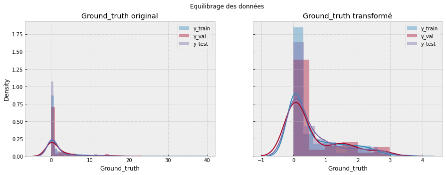

```python
fig, ax = plt.subplots(1,2,sharey=True,figsize=(15,5))
fig.suptitle('Equilibrage des données')
sns.distplot(y_train,label="y_train",ax=ax[0])
sns.distplot(y_val,label="y_val",ax=ax[0])
sns.distplot(y_test,label="y_test",ax=ax[0])
ax[0].title.set_text("Ground_truth original")
ax[0].legend()

# Transformation
minimum = min(min(y_train),min(y_test),min(y_val))
y_train = np.log(1+y_train)+min(y_train)
y_test = np.log(1+y_test)+min(y_test)
y_val = np.log(1+y_val)+min(y_val)

sns.distplot(y_train,label="y_train",ax=ax[1])
sns.distplot(y_val,label="y_val",ax=ax[1])
sns.distplot(y_test,label="y_test",ax=ax[1])
ax[1].title.set_text("Ground_truth transformé")
ax[1].legend()
plt.show()
```

#### On peut voir que l'échelle a complètement changée.

#### A présent, nous pouvons passer à la métrique, puis à la modelisation.

# Métrique : MAPE

```python
def compute_mape(y_pred,y_val):
    temp = np.abs(y_pred-y_val)/(np.array(y_val)+1)
    MAPE = (100/len(temp))*np.sum(temp)
    return MAPE
```

# Comparaison de modèles (hyperparamètres par défaut)

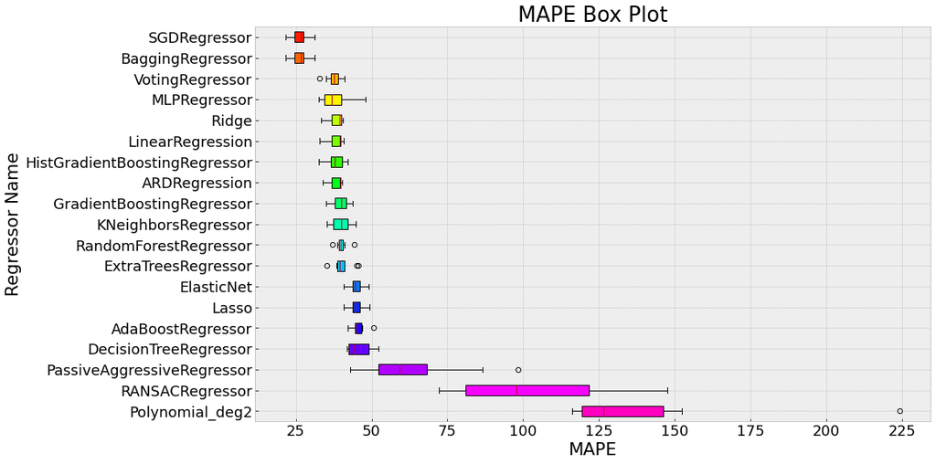

```python
reg_dict = {"LinearRegression": LinearRegression(),
            "Ridge": Ridge(),
            "Lasso": Lasso(),
            "ElasticNet": ElasticNet(),
            "Polynomial_deg2": Pipeline([('poly', PolynomialFeatures(degree=2)),('linear', LinearRegression())]),
            "KNeighborsRegressor": KNeighborsRegressor(n_neighbors=3),
            "DecisionTreeRegressor": DecisionTreeRegressor(),
            "RandomForestRegressor": RandomForestRegressor(n_estimators=10),
            "SGDRegressor": SGDRegressor(max_iter=30000, tol=1e-3, loss = 'huber', shuffle=True, epsilon=0.0001),
            "MLPRegressor": MLPRegressor(hidden_layer_sizes=(10,10), max_iter=1000, early_stopping=True, n_iter_no_change=5),
            "ExtraTreesRegressor": ExtraTreesRegressor(n_estimators=10),
            "PassiveAggressiveRegressor": PassiveAggressiveRegressor(max_iter=100, tol=1e-3),
            "RANSACRegressor": RANSACRegressor(random_state=0),
            "HistGradientBoostingRegressor": HistGradientBoostingRegressor(),
            "AdaBoostRegressor": AdaBoostRegressor(random_state=0, n_estimators=10),
            "BaggingRegressor": BaggingRegressor(base_estimator=SGDRegressor(max_iter=1000, tol=1e-3, loss = 'huber', shuffle=True, epsilon=0.0001), n_estimators=10),
            "GradientBoostingRegressor": GradientBoostingRegressor(random_state=0),
            "VotingRegressor": VotingRegressor([('lr', LinearRegression()), ('rf', RandomForestRegressor(n_estimators=10))]),
            "ARDRegression": ARDRegression()}

test_size = 0.2  #Rapport de division
N_trials = 10  #Nombre d'essais
mape_dict = {reg_name:[] for reg_name in reg_dict.keys()}

for i in tqdm(range(N_trials)):
    random_state = random.randint(0, 1000)
    trainset, valset = train_test_split(df_train, test_size=test_size, random_state=random_state)
    x_training = trainset.drop(['Ground_truth'],axis=1)
    y_training = trainset['Ground_truth']
    x_validation = valset.drop(['Ground_truth'],axis=1)
    y_validation = valset['Ground_truth']
    # Transformation
    minimum = min(min(y_training),min(y_validation))
    y_training = np.log(1+y_training)+min(y_training)
    y_validation = np.log(1+y_validation)+min(y_validation)

    for reg_name, reg in reg_dict.items():
        reg = make_pipeline(RobustScaler(),reg)
        start = time.time()
        reg.fit(x_training,y_training)
        mape = compute_mape(reg.predict(x_validation),y_validation)  #Calcul MAPE
        mape_dict[reg_name].append(mape)  #Stockage

#Trier par la valeur moyenne de MAPE
mape_dict_sorted = {key: value for key, value in reversed(sorted(mape_dict.items(), key=lambda x:np.mean(x[1])))}



plt.rcParams["font.size"] = 18  #Augmenter la taille de la police
scalarMap = cm.ScalarMappable(norm=Normalize(vmin=0, vmax=len(mape_dict)), cmap=plt.get_cmap('gist_rainbow_r'))

plt.figure(figsize=(15,9))
box=plt.boxplot(mape_dict_sorted.values(), vert=False, patch_artist=True,labels=mape_dict_sorted.keys())
for i, patch in enumerate(box['boxes']):
    patch.set_facecolor(scalarMap.to_rgba(i))
plt.title("MAPE Box Plot")
plt.xlabel("MAPE")
plt.ylabel("Regressor Name")
plt.show()
```

### What's wrong with Bagging and SGD ???

```python
reg_dict = {"SGDRegressor": SGDRegressor(max_iter=30000, tol=1e-3, loss = 'huber', shuffle=True, epsilon=0.0001),
            "BaggingRegressor": BaggingRegressor(base_estimator=SGDRegressor(max_iter=1000, tol=1e-3, loss = 'huber', shuffle=True, epsilon=0.0001), n_estimators=10)}

best_models_df = pd.DataFrame()
best_models_df["Ground_truth"] = y_val

for reg_name, reg in reg_dict.items():
    reg = make_pipeline(RobustScaler(),reg)
    start = time.time()
    reg.fit(X_train,y_train)
    mape = compute_mape(reg.predict(X_val),y_val)  #Calcul MAPE
    print(reg_name+"MAPE :",mape)
    best_models_df[reg_name] = reg.predict(X_val)
display(best_models_df.head())
```

```
SGDRegressorMAPE : 23.424722127700143
BaggingRegressorMAPE : 23.42470197541259
```

|  | Ground_truth | SGDRegressor | BaggingRegressor |
| --- | --- | --- | --- |
| 0 | 1.887070 | 0.002086 | 0.002120 |
| 1 | 2.525729 | 0.000807 | 0.000841 |
| 2 | 0.000000 | 0.002374 | 0.002394 |
| 3 | 0.000000 | 0.000099 | 0.000109 |
| 4 | 0.000000 | 0.000159 | 0.000168 |

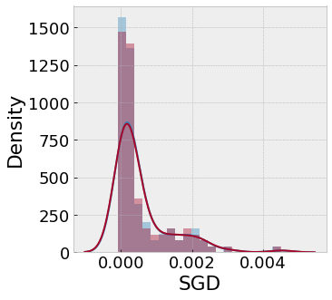

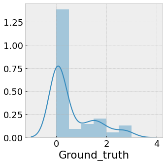

```python
fig = plt.figure(figsize=(5,5))
sns.distplot(best_models_df["SGDRegressor"], norm_hist=True)
sns.distplot(best_models_df["BaggingRegressor"], norm_hist=True)
plt.xlabel("SGD")
plt.show()
fig = plt.figure(figsize=(5,5))
sns.distplot(best_models_df["Ground_truth"], norm_hist=True)
plt.xlabel("Ground_truth")
plt.ylabel("")
plt.show()
```

# Modélisation

```python
print("MAPE_precip=",compute_mape(X_train["precip"],y_train))
print("-------")
print("MAPE_ws=",compute_mape(X_train["ws"],y_train))
print("-------")
print("MAPE_u10=",compute_mape(X_train["u10"],y_train))
```

```
MAPE_precip= 60.48376926198281
-------
MAPE_ws= 49.67066239241177
-------
MAPE_u10= 57.732392571386065
```

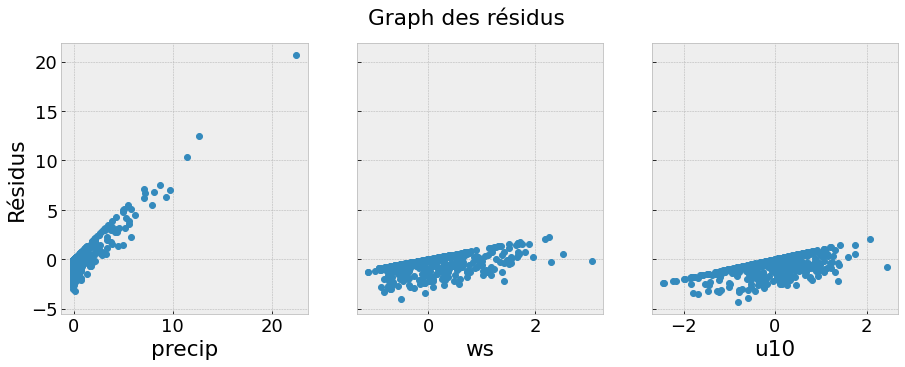

```python
fig, ax = plt.subplots(1,3,sharey=True,figsize=(15,5))
fig.suptitle('Graph des résidus')
ax[0].plot(X_train["precip"],X_train["precip"]-y_train,"o")
ax[0].set_xlabel("precip")
ax[0].set_ylabel("Résidus")
ax[1].plot(X_train["ws"],X_train["ws"]-y_train,"o")
ax[1].set_xlabel("ws")
ax[2].plot(X_train["u10"],X_train["u10"]-y_train,"o")
ax[2].set_xlabel("u10")
plt.show()
```

# LASSO

```
MAPE_lasso = 56.91620569853227
```

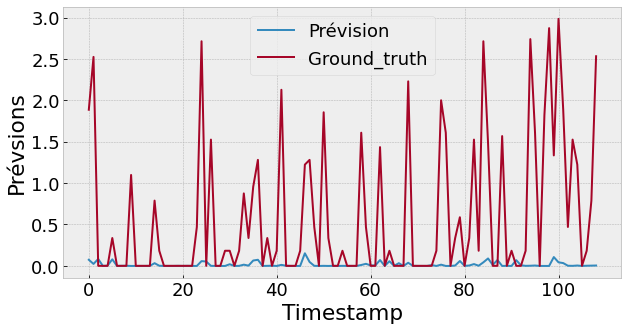

```python
regLasso = linear_model.Lasso(fit_intercept=False,normalize=False)
regLasso.fit(X_train,y_train)
prev=regLasso.predict(X_val)
print("MAPE_lasso =",compute_mape(y_val,prev))
plt.figure(figsize=(10,5))
plt.plot(prev)
plt.plot(y_val)
plt.xlabel(u"Timestamp")
plt.ylabel("Prévsions")
plt.legend(["Prévision","Ground_truth"])
plt.show()
```

### Let's add a penalization L1

```python
# grille de valeurs du paramètre alpha à optimiser
param=[{"alpha":[0.05,0.1,0.2,0.3,0.4,0.5,1]}]
regLasso_grid = GridSearchCV(linear_model.Lasso(fit_intercept=False), param,cv=5,n_jobs=-1)
regLassOpt=regLasso_grid.fit(X_train, y_train)
# paramètre optimal
best_lasso = regLassOpt.best_estimator_
best_prev = best_lasso.predict(X_val)
print("Meilleur paramètre = %s" % (regLassOpt.best_params_))
```

```
Meilleur paramètre = {'alpha': 0.05}
```

```
MAPE_lasso = 36.664963490138
```

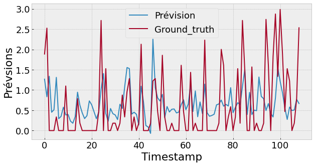

```python
print("MAPE_lasso =",compute_mape(y_val,best_prev))
plt.figure(figsize=(10,5))
plt.plot(best_prev)
plt.plot(y_val)
plt.xlabel("Timestamp")
plt.ylabel("Prévsions")
plt.legend(["Prévision","Ground_truth"])
plt.show()
```

```python
coef = pd.Series(regLassOpt.best_estimator_.coef_, index = X_train.columns)
print("Lasso conserve " + str(sum(coef != 0)) +
      " variables et en supprime " +  str(sum(coef == 0)))
```

```
Lasso conserve 8 variables et en supprime 17
```

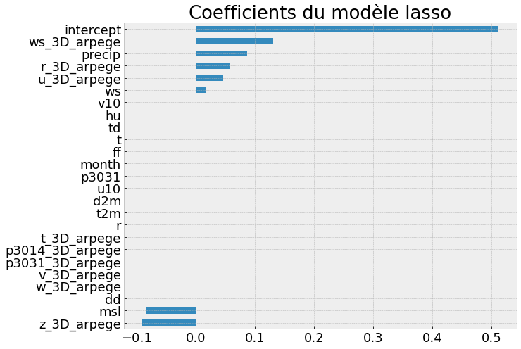

```python
imp_coef = coef.sort_values()
plt.figure(figsize=(10,8))
imp_coef.plot(kind = "barh")
plt.title(u"Coefficients du modèle lasso")
plt.show()
```

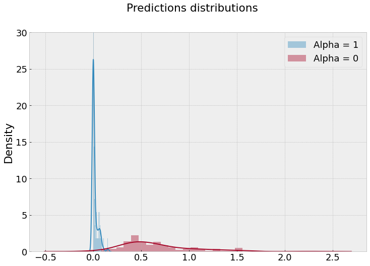

```python
plt.figure(figsize=(12,8))
sns.distplot(prev,label="Alpha = 1",bins=30)
sns.distplot(best_prev,label="Alpha = 0",bins=30)
plt.ylim([0,30])
plt.suptitle("Predictions distributions")
plt.legend()
plt.show()
```

# Commentaires

#### Lorsque α est trop élevé, tous les coefficients de la régression sont nuls, nous en avons une illustration ici ; lorsque α est trop faible, proche de 0, nous obtenons les coefficients de la régression linéaire multiple usuelle. Il faut trouver le juste milieu et c’est toute la difficulté de la régression Lasso. L’outil « Lasso path » peut nous y aider. Il produit un graphique qui met en relation les différentes versions de α avec les coefficients estimés. La régression Lasso, contrairement à Ridge, permet de réaliser une sélection de variables en mettant à zéro sélectivement les coefficients. Nous voyons ainsi se dessiner des scénarios de solutions (au sens « différents ensembles de variables sélectionnées ») tout au long du « Lasso path ».

## Important :

#### On pourra remarquer notamment la valeur du coefficient LASSO associé à la variable "intercept", cette valeur est en réalité très proche de la moyenne de la variable target "Ground_truth" associée à y_val (plus particulièrement ici de sa transformation : $$log(y_{val} + 1) + min(y_{val})$$

```python
print("Moyenne de la distribution de Ground_truth : ", y_val.mean())
print("Moyenne de la distribution de Ground_truth : ", best_prev.mean())
print("Coefficient de l'intercept : ", imp_coef["intercept"])
```

```
Moyenne de la distribution de Ground_truth :  0.5917719588838553
Moyenne de la distribution de Ground_truth :  0.6542569695120649
Coefficient de l'intercept :  0.5115627528526903
```

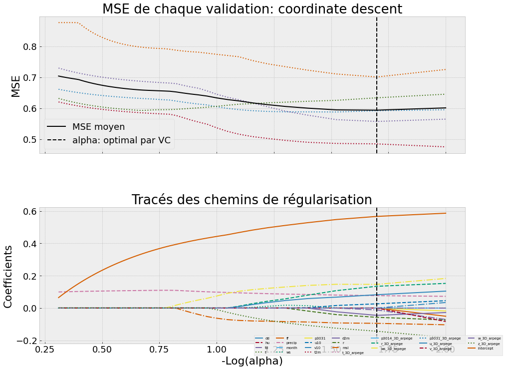

```python
alphas_lasso, coefs_lasso, _ = lasso_path(X_train,y_train, alphas=np.array(range(1,50,1))/100.,)
model = LassoCV(cv=5, alphas=np.array(range(1,50,1))/100.,n_jobs=-1,random_state=13).fit(X_train,y_train)
m_log_alphas = -np.log10(model.alphas_)


fig, ax = plt.subplots(2,1,sharex=True,figsize=(15,12))
fig.tight_layout(pad=5)
ax[0].plot(m_log_alphas, model.mse_path_, ':')
ax[0].plot(m_log_alphas, model.mse_path_.mean(axis=-1), 'k',
         label='MSE moyen', linewidth=2)
ax[0].axvline(-np.log10(model.alpha_), linestyle='--', color='k',
            label='alpha: optimal par VC')
ax[0].set_ylabel('MSE')
ax[0].legend()
ax[0].title.set_text('MSE de chaque validation: coordinate descent')
styles = cycle(['-', '--', '-.', ':'])
neg_log_alphas_lasso = -np.log10(alphas_lasso)
legend = []
i=0
for coef_l, s in zip(coefs_lasso, styles):
    i+=1
    l1 = ax[1].plot(neg_log_alphas_lasso, coef_l, linestyle=s)
    legend.append("Chemin de régularisation "+str(i))
ax[1].set_xlabel('-Log(alpha)')
ax[1].axvline(-np.log10(model.alpha_), linestyle='--', color='k',
            label='alpha: optimal par VC')
ax[1].set_ylabel('Coefficients')
ax[1].legend(X_train.columns,loc='lower left', prop={'size': 7},bbox_to_anchor=(0.5, -0.1),fancybox=False, shadow=False, ncol=7)
ax[1].title.set_text('Tracés des chemins de régularisation')
plt.show()
```

## Commentaires

#### Par défaut, il y a **8 variables explicatives significative** (voir cellule 14)

#### A ce stade, nous pourrions sélectionner uniquement les variables significatives

#### Le meilleur modèle LASSO reste ainsi celui avec une pénalisation dont la valeur alpha vaut $\alpha = 10^{-1.7} = 0.02$

# SVR (justifier choix du noyau)

### Choix du noyau :

- **Linear kernel** : $k(x,x') = <x,x'>$
- p **degree polynomial kernel** : $k(x,x') = (1+<x,x'>)^p$
- **RBD (Gaussian kernel)** : $k(x,x') = e^{-\frac{\|x-x'\|^2}{2\sigma^2}}$
- **Sigmoid kernel** : $k(x,x') = tanh(\kappa<x,x'>+\theta)$

#### On peut d'ores et déjà éliminer le noyau sigmoid qui n'est pas défini positif, car le résultat produit n'aide pas à la régression.

#### Nous pouvons également éliminer le noyau linéaire car on a vu qu'il était très dur de déduire un comportement linéaire des données.

#### Il reste donc deux noyaux qui semblent prometteurs : le noyau Gaussien et le noyau Polynomial :

```python
param=[{"C":[0.1,0.2,0.3,0.4,0.5],"kernel":["poly","rbf"],"epsilon":[0.2,0.3,0.4,0.5],"degree":[2,3,4,5,6,7,8,9]}]
svm_grid= GridSearchCV(SVR(),param,cv=10,n_jobs=-1)
svmOpt=svm_grid.fit(X_train, y_train)
# paramètre optimal
print("Meilleurs paramètres = %s" % (svmOpt.best_params_))
```

```
Meilleurs paramètres = {'C': 0.4, 'degree': 2, 'epsilon': 0.4, 'kernel': 'rbf'}
```

```
MAPE_svr = 36.093140537925585
```

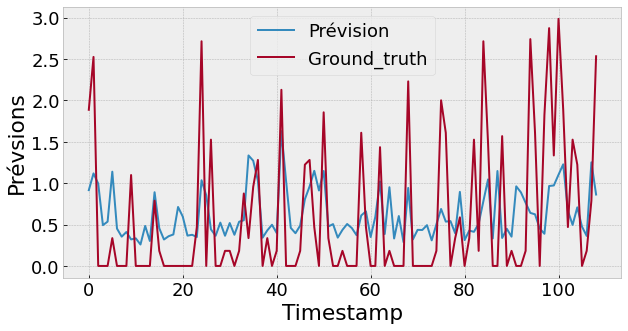

```python
# prévision de l'échantillon test
y_chap = svmOpt.best_estimator_.predict(X_val)
print("MAPE_svr =",compute_mape(y_val,y_chap))
plt.figure(figsize=(10,5))
plt.plot(y_chap)
plt.plot(y_val)
plt.xlabel(u"Timestamp")
plt.ylabel("Prévsions")
plt.legend(["Prévision","Ground_truth"])
plt.show()
```

# DecisionTreeRegressor

```python
dtr = DecisionTreeRegressor()
params = {
    "criterion": ["squared_error"],
    "splitter": ["best","random"],
    "min_samples_split" : np.arange(2,30,3),
    "min_samples_leaf": np.arange(2,35,3),
}

dtr_grid = GridSearchCV(dtr,params, cv=10, n_jobs=-1,verbose=1)
dtr_grid.fit(X_train,y_train)
print(dtr_grid.best_params_)
```

```
Fitting 10 folds for each of 220 candidates, totalling 2200 fits
{'criterion': 'squared_error', 'min_samples_leaf': 26, 'min_samples_split': 2, 'splitter': 'random'}
```

```
MAPE_dtr = 36.37563550497839
```

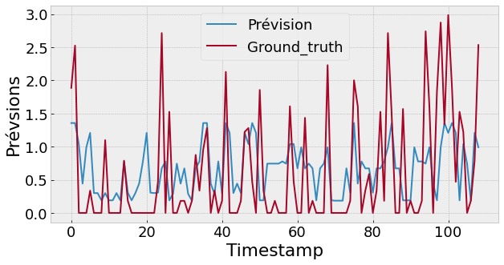

```python
# Prévision de l'échantillon test
y_dtr = dtr_grid.best_estimator_.predict(X_val)
print("MAPE_dtr =",compute_mape(y_val,y_dtr))
plt.figure(figsize=(10,5))
plt.plot(y_dtr)
plt.plot(y_val)
plt.xlabel(u"Timestamp")
plt.ylabel("Prévsions")
plt.legend(["Prévision","Ground_truth"])
plt.show()
```

```python
import graphviz
from sklearn import tree
# DOT data
dot_data = tree.export_graphviz(dtr_grid.best_estimator_,filled=True,feature_names=X_train.columns)

# Draw graph
graph = graphviz.Source(dot_data, format="png");
graph
```

[figure not shown]

# Random Forest

```python
# Create the parameter grid based on the results of random search
param_grid = {
    'bootstrap': [True],
    'max_depth': [90,110,130,150],
    'max_features': [2, 3],
    'min_samples_leaf': [2,3,4],
    'min_samples_split': [10,12,14,16],
    'n_estimators': [100, 150, 200, 250, 300]
}
# Create a based model
rf = RandomForestRegressor()
# Instantiate the grid search model
rf_grid = GridSearchCV(estimator = rf, param_grid = param_grid,
                          cv = 5, n_jobs = -1, verbose = 1)
# Fit the grid search to the data
rf_grid.fit(X_train, y_train)
print(rf_grid.best_params_)
```

```
Fitting 5 folds for each of 480 candidates, totalling 2400 fits
{'bootstrap': True, 'max_depth': 110, 'max_features': 2, 'min_samples_leaf': 3, 'min_samples_split': 10, 'n_estimators': 100}
```

```
MAPE_rf = 35.0652863388581
```

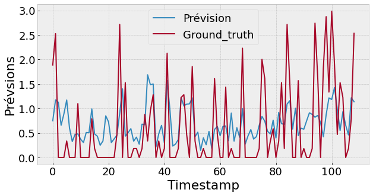

```python
# Prévision de l'échantillon test
y_rf = rf_grid.best_estimator_.predict(X_val)
print("MAPE_rf =",compute_mape(y_val,y_rf))
plt.figure(figsize=(10,5))
plt.plot(y_rf)
plt.plot(y_val)
plt.xlabel(u"Timestamp")
plt.ylabel("Prévsions")
plt.legend(["Prévision","Ground_truth"])
plt.show()
```

# Boosting

#### What is a Tweedie Distribution?

The Tweedie distribution is a special case of an **exponential distribution**. It can have a cluster of data items at zero (called a “point mass”),  
which is particularly useful for modeling claims in the insurance industry, in medical/genomic testing, or anywhere else there is a mixture of zeros  
and non-negative data points. Basically, if you see a histogram with a spike at zero, it’s a possible candidate to be fitted to a Tweedie model.

[figure not shown]

*The Tweedie distribution has a point mass at zero before following a “regular” exponential curve.*

The Tweedie distribution is actually a family of distributions that are a subset of Exponential Dispersion Models(EDMs).  
EDMs are two-parameter distributions from the linear exponential family that have a scale parameter φ.

#### Mean, Variance and Shape

This family of distributions has the following characteristics:

- a mean of $E(Y) = μ$
- a variance of $Var(Y) = φ*μ^p$.

The p in the variance function is an additional shape parameter for the distribution. “p” is sometimes written in terms of the shape parameter α:  
p = (α – 2) / (α -1).  
Some familiar distributions are special cases of the Tweedie distribution:

- p = 0 : Normal distribution,
- p = 1: Poisson distribution,
- 1 < p < 2: Compound Poisson/gamma distribution (non-negative with mass at zero),
- p = 2 gamma distribution,
- 2 < p < 3 Positive stable distributions,
- p = 3: Inverse Gaussian distribution / Wald distribution,
- p > 3: Positive stable distributions,
- p = ∞ Extreme stable distributions.

The distribution is not defined for values of “p” from 0 to 1

[figure not shown]

```python
xgb = XGBRegressor()
parameters = {'tree_method': ['hist','approx'],
              'objective':["reg:tweedie"],
              'tweedie_variance_power': [1.1],
              "eval_metric":["tweedie-nloglik@1.1"],
              'learning_rate': [1e-1,5e-2,1e-2], #so called `eta` value
              'n_estimators': np.arange(10,100,10)
}
xgb_grid = GridSearchCV(xgb,
                        parameters,
                        cv = 8,
                        n_jobs = -1,
                        verbose=False)

xgb_grid.fit(X_train,y_train,verbose=0);
```

```python
print(xgb_grid.best_params_)
```

```
{'eval_metric': 'tweedie-nloglik@1.1', 'learning_rate': 0.05, 'n_estimators': 30, 'objective': 'reg:tweedie', 'tree_method': 'approx', 'tweedie_variance_power': 1.1}
```

```
MAPE_xgb = 34.29852964773257
```

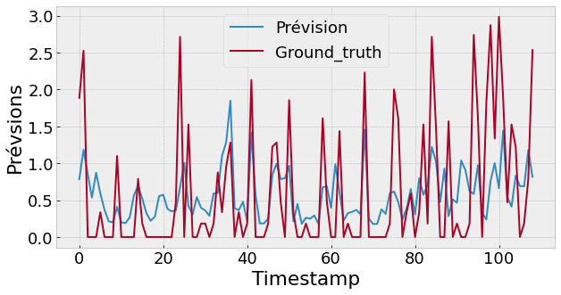

```python
# prévision de l'échantillon test
y_xgb = xgb_grid.best_estimator_.predict(X_val)
print("MAPE_xgb =",compute_mape(y_val,y_xgb))
plt.figure(figsize=(10,5))
plt.plot(y_xgb)
plt.plot(y_val)
plt.xlabel(u"Timestamp")
plt.ylabel("Prévsions")
plt.legend(["Prévision","Ground_truth"])
plt.show()
```

# Réseau de neurones

```python
X_train = X_train.drop("intercept",axis=1)
X_val = X_val.drop("intercept",axis=1)
X_test = X_test.drop("intercept",axis=1)
```

#### La régularisation limite l'ampleur des poids du modèle en ajoutant une pénalité pour les poids à la fonction d'erreur de modèle.

La régularisation L1 utilise la somme des valeurs absolues des poids. La régularisation L2 utilise la somme des valeurs des poids au carré.

- L2-Regularization permet d’effectuer un apprentissage plus rapide (entre autres)
- L1-Regularization permet d’effectuer une feature selection plus précise (trouver des sous-ensembles de données pertinents). Elle est également plus robust aux outliers

#### Nous avons l'équation de régression 𝑦=𝑊𝑥+𝑏, où 𝑥 est l'entrée, 𝑊 est la matrice de poids 𝑏 le biais.

- Kernel Regularizer : essaie de réduire les poids 𝑊 (hors biais).
- Bias Regularizer : tente de réduire le biais 𝑏.
- Activity Regularizer : essaie de réduire la sortie de la couche 𝑦, réduira ainsi les poids et ajustera le biais de sorte que 𝑊𝑥+𝑏 soit le plus petit.

#### La régularisation : laquelle utiliser ?

Habituellement, si vous n'avez pas d'a priori sur la distribution que vous souhaitez modéliser, vous n'utiliserez que le régularisateur du noyau, car un réseau suffisamment grand peut toujours modéliser votre fonction même si la régularisation sur les poids est importante.

Si vous voulez que la fonction de sortie passe par (ou ait une interception plus proche de) l'origine, vous pouvez utiliser le régularisateur de biais.

Si vous souhaitez que la sortie soit plus petite (ou plus proche de 0), vous pouvez utiliser le régularisateur d'activité.

#### 𝐿1 vs 𝐿2 regularization

Maintenant, pour la perte de 𝐿1 contre 𝐿2 pour la perte de poids (à ne pas confondre avec la fonction de perte de sorties) :

- La perte de 𝐿2 est définie comme $𝑤^2$
- La perte de 𝐿1 est définie comme |𝑤|.

où 𝑤 est une composante de la matrice 𝑊.

- Le gradient de 𝐿2 sera : 2𝑤
- Le gradient de 𝐿1 sera : 𝑠𝑖𝑔𝑛(𝑤)

Ainsi, pour chaque mise à jour du gradient avec un taux d'apprentissage 𝑎, en perte 𝐿2, les poids seront soustraits de 𝑎𝑊, tandis qu'en perte 𝐿1, ils seront soustraits de 𝑎⋅𝑠𝑖𝑔𝑛(𝑊).

L'effet de la perte 𝐿2 sur les poids est une réduction des grandes composantes dans la matrice 𝑊, tandis que la perte 𝐿1 rendra la matrice des poids "sparse", avec de nombreuses valeurs nulles.

Il en va de même pour le biais et la sortie en utilisant respectivement le bias_regularizer et le activity_regularizer.

```python
ann = Sequential()
ann.add(BatchNormalization())
ann.add(Dense(24 ,activation="relu", kernel_initializer='normal', bias_initializer='zeros', kernel_regularizer=regularizers.l1(1e-1)))
ann.add(Dropout(0.2))
ann.add(Dense(256, activation="relu", kernel_initializer='normal', bias_initializer='zeros', kernel_regularizer=regularizers.l1(1e-1)))
ann.add(Dropout(0.2))
ann.add(Dense(124, activation="tanh", kernel_initializer='normal', bias_initializer='zeros', kernel_regularizer=regularizers.l1(1e-1)))
ann.add(Dense(1))

keras.backend.set_epsilon(1)
# Solves problem of really high metric :
# https://stackoverflow.com/questions/49729522/why-is-the-mean-average-percentage-errormape-extremely-high

callback = keras.callbacks.EarlyStopping(monitor='val_loss', patience=40)

ann.compile(loss='mean_absolute_percentage_error', optimizer='adam', metrics=['mean_absolute_percentage_error'])

history = ann.fit(X_train,y_train,epochs=100, batch_size=15, verbose = 0, validation_data=(X_val,y_val), callbacks=[callback])

history_dict = history.history
print("Ann train MAPE :",round(history_dict['mean_absolute_percentage_error'][-1],2))
print("Ann val MAPE :",round(history_dict['val_mean_absolute_percentage_error'][-1],2))

print("MAPE on Testset (data never seen by the NN): ",round(compute_mape(np.array(np.exp(ann.predict(X_test)-minimum)-1).reshape(-1),y_test),2))
```

```
Metal device set to: Apple M1

systemMemory: 8.00 GB
maxCacheSize: 2.67 GB
```

[output not shown]

```
Ann train MAPE : 29.5
Ann val MAPE : 31.48
MAPE on Testset (data never seen by the NN):  36.47
```

```
2022-03-14 16:12:52.059285: I tensorflow/core/grappler/optimizers/custom_graph_optimizer_registry.cc:113] Plugin optimizer for device_type GPU is enabled.
```

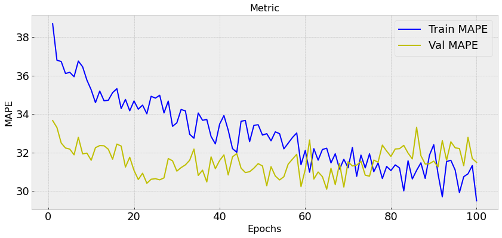

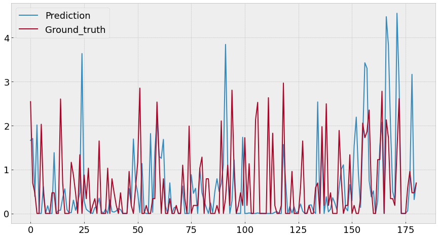

```python
train_mape = history_dict['mean_absolute_percentage_error']
val_mape = history_dict['val_mean_absolute_percentage_error']

epochs = range(1, len(val_mape) + 1)

plt.figure(figsize=(14, 6))
plt.plot(epochs, train_mape, 'b', label='Train MAPE')
plt.plot(epochs, val_mape, 'y', label='Val MAPE')
plt.title('Metric', fontsize=16)
plt.xlabel('Epochs', fontsize=16)
plt.ylabel('MAPE', fontsize=16)
plt.legend()
plt.show()

plt.figure(figsize=(15,8))
plt.plot(np.exp(ann.predict(X_test)-minimum)-1,label="Prediction")
plt.plot(y_test,label="Ground_truth")
plt.legend()
plt.show()
```